# Project: Identify Customer Segments

### Step 2.3: Interpret Principal Components

Now that we have our transformed principal components, it's a nice idea to check out the weight of each variable on the first few components to see if they can be interpreted in some fashion.

As a reminder, each principal component is a unit vector that points in the direction of highest variance (after accounting for the variance captured by earlier principal components). The further a weight is from zero, the more the principal component is in the direction of the corresponding feature. If two features have large weights of the same sign (both positive or both negative), then increases in one tend expect to be associated with increases in the other. To contrast, features with different signs can be expected to show a negative correlation: increases in one variable should result in a decrease in the other.

- To investigate the features, you should map each weight to their corresponding feature name, then sort the features according to weight. The most interesting features for each principal component, then, will be those at the beginning and end of the sorted list. Use the data dictionary document to help you understand these most prominent features, their relationships, and what a positive or negative value on the principal component might indicate.
- You should investigate and interpret feature associations from the first three principal components in this substep. To help facilitate this, you should write a function that you can call at any time to print the sorted list of feature weights, for the *i*-th principal component. This might come in handy in the next step of the project, when you interpret the tendencies of the discovered clusters.

```python
# Map weights for the first principal component to corresponding feature names
# and then print the linked values, sorted by weight.
# HINT: Try defining a function here or in a new cell that you can reuse in the
# other cells.

# Function that creates a dataframe of the PCA results and finds a component and its realted weights based
# on its index, column values sorted in descending order
def pca_weights(df_scaled, pca, i):
    components = pd.DataFrame(np.round(pca.components_, 3), columns=df_scaled.keys())
    weights = components.iloc[i].sort_values(ascending=False)
    return weights
```

```python
# 1st principal component and corresponding feature weights
pca_weights(az_lownan_scaled, pca, 0)
```

```
LP_STATUS_GROB_1.0          0.185
HH_EINKOMMEN_SCORE          0.173
PLZ8_ANTG3                  0.172
WEALTH                      0.171
PLZ8_ANTG4                  0.166
ORTSGR_KLS9                 0.148
EWDICHTE                    0.146
FINANZ_HAUSBAUER            0.142
LP_STATUS_FEIN_1.0          0.125
KBA05_ANTG4                 0.121
PLZ8_ANTG2                  0.119
KBA05_ANTG3                 0.111
ANZ_HAUSHALTE_AKTIV         0.108
ARBEIT                      0.107
PLZ8_BAUMAX_5.0             0.105
CAMEO_DEUG_2015_9           0.105
LP_STATUS_FEIN_2.0          0.103
LP_LEBENSPHASE_GROB_1.0     0.101
RELAT_AB                    0.101
FINANZTYP_1                 0.100
FINANZ_SPARER               0.098
MOVEMENT                    0.095
CAMEO_DEUG_2015_8           0.087
LP_FAMILIE_FEIN_1.0         0.085
LP_FAMILIE_GROB_1.0         0.085
LP_LEBENSPHASE_FEIN_1.0     0.084
PLZ8_BAUMAX_4.0             0.076
SEMIO_PFLICHT               0.069
ZABEOTYP_5                  0.068
WOHNLAGE_4.0                0.066
                            ...
LP_FAMILIE_GROB_5.0        -0.063
LP_LEBENSPHASE_GROB_5.0    -0.065
LP_LEBENSPHASE_GROB_3.0    -0.067
CAMEO_DEUG_2015_4          -0.068
FINANZ_VORSORGER           -0.069
ALTERSKATEGORIE_GROB       -0.069
FINANZTYP_2                -0.069
ANZ_PERSONEN               -0.080
CAMEO_DEUG_2015_2          -0.081
GEBAEUDETYP_1.0            -0.082
LP_LEBENSPHASE_GROB_12.0   -0.089
GEBAEUDETYP_RASTER         -0.090
ZABEOTYP_1                 -0.090
BALLRAUM                   -0.091
GREEN_AVANTGARDE           -0.095
WOHNLAGE_7.0               -0.099
LIFE_STAGE                 -0.101
LP_STATUS_GROB_5.0         -0.106
LP_STATUS_FEIN_9.0         -0.106
LP_STATUS_FEIN_10.0        -0.106
LP_STATUS_GROB_4.0         -0.109
INNENSTADT                 -0.120
PLZ8_GBZ                   -0.126
KONSUMNAEHE                -0.128
PLZ8_BAUMAX_1.0            -0.162
KBA05_GBZ                  -0.169
PLZ8_ANTG1                 -0.173
FINANZ_MINIMALIST          -0.175
KBA05_ANTG1                -0.176
MOBI_REGIO                 -0.191
Name: 0, Length: 257, dtype: float64
```

```python
# Map weights for the second principal component to corresponding feature names
# and then print the linked values, sorted by weight.

# 2nd principal component and corresponding feature weights
pca_weights(az_lownan_scaled, pca, 1)
```

```
ALTERSKATEGORIE_GROB        0.221
FINANZ_VORSORGER            0.213
ZABEOTYP_3                  0.188
SEMIO_ERL                   0.163
SEMIO_LUST                  0.154
RETOURTYP_BK_S              0.150
LP_LEBENSPHASE_GROB_2.0     0.145
W_KEIT_KIND_HH              0.123
LP_LEBENSPHASE_FEIN_6.0     0.105
CJT_GESAMTTYP_2.0           0.102
FINANZ_MINIMALIST           0.096
FINANZTYP_5                 0.096
FINANZTYP_2                 0.089
LP_STATUS_FEIN_1.0          0.087
FINANZ_HAUSBAUER            0.073
LP_LEBENSPHASE_FEIN_8.0     0.072
CJT_GESAMTTYP_1.0           0.068
FINANZTYP_6                 0.066
SHOPPER_TYP_3.0             0.065
NATIONALITAET_KZ_1.0        0.063
SEMIO_KRIT                  0.060
LP_LEBENSPHASE_FEIN_5.0     0.057
LP_FAMILIE_GROB_1.0         0.057
LP_FAMILIE_FEIN_1.0         0.057
GFK_URLAUBERTYP_4.0         0.055
WOHNDAUER_2008              0.053
EWDICHTE                    0.052
ORTSGR_KLS9                 0.051
PLZ8_ANTG3                  0.051
LP_STATUS_FEIN_3.0          0.048
                            ...
SEMIO_SOZ                  -0.052
LP_LEBENSPHASE_GROB_7.0    -0.052
LP_LEBENSPHASE_FEIN_29.0   -0.055
ANZ_PERSONEN               -0.059
LP_LEBENSPHASE_GROB_11.0   -0.064
LP_LEBENSPHASE_FEIN_30.0   -0.066
FINANZTYP_3                -0.067
GFK_URLAUBERTYP_9.0        -0.070
LP_FAMILIE_GROB_4.0        -0.070
LP_LEBENSPHASE_FEIN_1.0    -0.074
LP_STATUS_FEIN_5.0         -0.076
FINANZTYP_4                -0.083
LP_LEBENSPHASE_GROB_9.0    -0.086
ZABEOTYP_5                 -0.092
LP_STATUS_FEIN_2.0         -0.096
LP_LEBENSPHASE_GROB_1.0    -0.099
ZABEOTYP_4                 -0.104
SEMIO_FAM                  -0.118
SEMIO_MAT                  -0.120
FINANZTYP_1                -0.134
SEMIO_KULT                 -0.146
ONLINE_AFFINITAET          -0.153
SEMIO_RAT                  -0.163
SEMIO_PFLICHT              -0.194
SEMIO_TRADV                -0.196
SEMIO_REL                  -0.197
FINANZ_ANLEGER             -0.198
FINANZ_UNAUFFAELLIGER      -0.207
FINANZ_SPARER              -0.222
DECADE                     -0.231
Name: 1, Length: 257, dtype: float64
```

```python
# Map weights for the third principal component to corresponding feature names
# and then print the linked values, sorted by weight.

# 3rd principal component and corresponding feature weights
pca_weights(az_lownan_scaled, pca, 2)
```

```
SEMIO_VERT                  0.294
SEMIO_FAM                   0.245
SEMIO_SOZ                   0.242
SEMIO_KULT                  0.239
FINANZTYP_5                 0.132
ZABEOTYP_1                  0.127
FINANZ_MINIMALIST           0.124
GREEN_AVANTGARDE            0.121
SEMIO_REL                   0.116
SHOPPER_TYP_0.0             0.112
LP_STATUS_GROB_5.0          0.098
LP_STATUS_FEIN_10.0         0.098
ORTSGR_KLS9                 0.092
EWDICHTE                    0.091
SEMIO_MAT                   0.090
RETOURTYP_BK_S              0.062
PLZ8_ANTG3                  0.060
PLZ8_ANTG4                  0.060
PLZ8_BAUMAX_5.0             0.053
LP_STATUS_GROB_3.0          0.050
W_KEIT_KIND_HH              0.048
SHOPPER_TYP_1.0             0.048
RELAT_AB                    0.046
PLZ8_ANTG2                  0.045
ARBEIT                      0.043
LP_LEBENSPHASE_FEIN_20.0    0.043
LP_LEBENSPHASE_FEIN_13.0    0.041
LP_LEBENSPHASE_FEIN_40.0    0.040
ZABEOTYP_6                  0.040
LP_LEBENSPHASE_FEIN_35.0    0.040
                            ...
SHOPPER_TYP_3.0            -0.046
GEBAEUDETYP_RASTER         -0.048
LP_LEBENSPHASE_FEIN_21.0   -0.052
PLZ8_ANTG1                 -0.053
LP_STATUS_GROB_2.0         -0.053
ZABEOTYP_3                 -0.054
LP_FAMILIE_FEIN_4.0        -0.054
PLZ8_BAUMAX_1.0            -0.057
KKK                        -0.057
ZABEOTYP_4                 -0.060
KONSUMNAEHE                -0.061
HH_EINKOMMEN_SCORE         -0.066
LP_STATUS_FEIN_2.0         -0.068
WOHNLAGE_7.0               -0.070
BALLRAUM                   -0.071
FINANZ_HAUSBAUER           -0.073
LP_FAMILIE_GROB_3.0        -0.078
LP_LEBENSPHASE_GROB_6.0    -0.078
INNENSTADT                 -0.078
SHOPPER_TYP_2.0            -0.086
FINANZTYP_1                -0.088
LP_STATUS_FEIN_4.0         -0.099
MOVEMENT                   -0.121
SEMIO_RAT                  -0.128
FINANZ_ANLEGER             -0.145
SEMIO_ERL                  -0.203
SEMIO_DOM                  -0.249
SEMIO_KRIT                 -0.251
SEMIO_KAEM                 -0.283
ANREDE_KZ                  -0.317
Name: 2, Length: 257, dtype: float64
```

### Discussion 2.3: Interpret Principal Components

**Above we can see the three prinicipal components that explain the most variance in the dataset and how these are influenced by the features. The further a feature weight is from zero, the more the principal component is in the direction of that feature.**

**Looking more in-depth at the first principal component, we can see that *LP_STATUS_GROB_1.0*, *HH_EINKOMMEN_SCORE* and *PLZ8_ANTG3* have a positive correlation. If the number of low-income earners (social status) increase, the estimated household net incom column tend to increase as well, a higher number in this column means lower household income and it makes a lot of sense that these columns increase and decrease together. When these two increase, the share of 6-10 family homes in the the PLZ8 region also tend to increase.**

**Features *FINANZ_MINIMALIST*, *KBA05_ANTG1* and *MOBI_REGIO* are the features least associated with the first principal component and they also have a positive correlation. It means that an increase in the share of 1-2 family homes in the microcell tends to mean an increase in the column with financial typology low financial interest, which means that the share of people with low finanical interest decreases (a higher number in this column means a lower interest in that column). If these columns increase the movement patterns column also tend to increase, which means the movement pattern gets very low to none (a higher number in this column means a lower movement pattern).**

**The three columns that are most strongly associated to the first component *LP_STATUS_GROB_1.0*, *HH_EINKOMMEN_SCORE* and *PLZ8_ANTG3*, have a negative correlation with the three columns that were the least associated with the component, *FINANZ_MINIMALIST*, *KBA05_ANTG1* and *MOBI_REGIO*. This means that an increase in the first three tends to mean a decrease in the last three.**

**The second principal component has a positive association with features:**

**ALTERSKATEGORIE_GROB - Estimated age based on given name analysis (a higher value means older) FINANZ_VORSORGER - Financial typology, 'be prepared' (a higher value means lower) ZABEOTYP_3 - Energy consumption typology, fair supplied**

**and a negative association with features:**

**FINANZ_UNAUFFAELLIGER - Financial typology, 'inconspicuous' (a lower value means higher) FINANZ_SPARER - Financial typology, 'money-saver' (a lower value means higher) DECADE - Dominating movement of person's youth, decade (a lower value means an earlier decade)**

**This component seems to be related to older people that are not financially prepared with a fair supplied energy consumption. This component is also related to financially inconspicuous people that are money-savers, with the dominating decade of the youth of these people being close to or during the 40s.**

**The third principal component has a positive association with features:**

**SEMIO_VERT - Personality typology, 'dreamful' (a higher value means lower affinity) SEMIO_FAM - Personality typology, 'family-minded' (a higher value means lower affinity) SEMIO_SOZ - Personality typology, 'socially-minded' (a higher value means lower affinity)**

**and a negative association with features:**

**SEMIO_KRIT - Personality typology, 'critical-minded' (a lower value means higher affinity) SEMIO_KAEM - Personality typology, 'combative attitude' (a lower value means higher affinity) ANREDE_KZ - Gender (a lower value means male)**

**The third component appears to be related to people far away from having a dreamful, family-oriented and socially-minded personality type. The people associated with this component have a critical-minded personality and combative attitude and tend to be male.**

## Step 3: Clustering

### Step 3.1: Apply Clustering to General Population

You've assessed and cleaned the demographics data, then scaled and transformed them. Now, it's time to see how the data clusters in the principal components space. In this substep, you will apply k-means clustering to the dataset and use the average within-cluster distances from each point to their assigned cluster's centroid to decide on a number of clusters to keep.

- Use sklearn's KMeans class to perform k-means clustering on the PCA-transformed data.
- Then, compute the average difference from each point to its assigned cluster's center. **Hint**: The KMeans object's `.score()` method might be useful here, but note that in sklearn, scores tend to be defined so that larger is better. Try applying it to a small, toy dataset, or use an internet search to help your understanding.
- Perform the above two steps for a number of different cluster counts. You can then see how the average distance decreases with an increasing number of clusters. However, each additional cluster provides a smaller net benefit. Use this fact to select a final number of clusters in which to group the data. **Warning**: because of the large size of the dataset, it can take a long time for the algorithm to resolve. The more clusters to fit, the longer the algorithm will take. You should test for cluster counts through at least 10 clusters to get the full picture, but you shouldn't need to test for a number of clusters above about 30.
- Once you've selected a final number of clusters to use, re-fit a KMeans instance to perform the clustering operation. Make sure that you also obtain the cluster assignments for the general demographics data, since you'll be using them in the final Step 3.3.

```python
# Function to calculate the kmeans score regarding SSE (sum of squared errors) for points to centroids, based
# on desired number of clusters/centroids (the k value)
def kmeans_score(df_pca, n_clusters):
    kmeans = KMeans(n_clusters)
    model = kmeans.fit(df_pca)
    score = np.abs(model.score(df_pca))

    return score
```

```python
# Over a number of different cluster counts...
    # run k-means clustering on the data and...
    # compute the average within-cluster distances.

# For loop to iterate kmeans score calculation over number of clusters and add score to scores list
start = time.time()
print('Starting calculation')

scores = []
clusters = list(range(10,30))

for k in clusters:
    scores.append(kmeans_score(az_lownan_pca, k))

time_elapsed = time.time() - start
print('Time spent calculating kmeans scores: {:.0f}m {:.0f}s'.format(time_elapsed // 60, time_elapsed % 60))
```

```
Starting calculation
Time spent calculating kmeans scores: 116m 51s
```

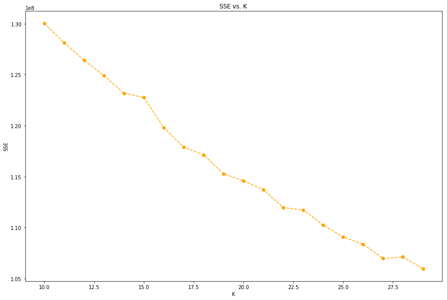

```python
# Investigate the change in within-cluster distance across number of clusters.
# HINT: Use matplotlib's plot function to visualize this relationship.

# Plot SSE scores against number of clusters (k)
plt.figure(figsize=(15, 10))
plt.plot(clusters, scores, linestyle='--', marker='o', color='orange')
plt.xlabel('K')
plt.ylabel('SSE')
plt.title('SSE vs. K');
```

```python
s7 = pd.Series(clusters, name='clusters')
s8 = pd.Series(scores, name='scores')
s8 = s8.round(decimals=1)

k_scores = pd.concat([s7, s8], axis=1)

# Print table with missing data and difference, show all columns
#with pd.options.display.float_format = '{:.4f}'.format:
#    display(k_scores.sort_values(by=['scores']))

k_scores
```

|  | clusters | scores |
| --- | --- | --- |
| 0 | 10 | 130031847.7 |
| 1 | 11 | 128145749.1 |
| 2 | 12 | 126417783.5 |
| 3 | 13 | 124909176.9 |
| 4 | 14 | 123174173.6 |
| 5 | 15 | 122770237.0 |
| 6 | 16 | 119809003.4 |
| 7 | 17 | 117891555.0 |
| 8 | 18 | 117127694.4 |
| 9 | 19 | 115284722.7 |
| 10 | 20 | 114593886.7 |
| 11 | 21 | 113720919.4 |
| 12 | 22 | 111973472.5 |
| 13 | 23 | 111740147.4 |
| 14 | 24 | 110265099.3 |
| 15 | 25 | 109080989.1 |
| 16 | 26 | 108387438.9 |
| 17 | 27 | 106986508.4 |
| 18 | 28 | 107141191.1 |
| 19 | 29 | 105976206.2 |

```python
# Re-fit the k-means model with the selected number of clusters and obtain
# cluster predictions for the general population demographics data.

start = time.time()
print('Starting predicting')

kmeans = KMeans(27)
model = kmeans.fit(az_lownan_pca)
az_lownan_predicted = model.predict(az_lownan_pca)

time_elapsed = time.time() - start
print('Time spent on cluster prediction: {:.0f}m {:.0f}s'.format(time_elapsed // 60, time_elapsed % 60))
```

```
Starting predicting
Time spent on cluster prediction: 6m 58s
```

### Discussion 3.1: Apply Clustering to General Population

**The k-means score calculation looped through 10 to 29 clusters. The plot shows the k-mean score (SSE - sum of squared errors) for the different number of clusters. There is no clear elbow in the shape of the graph line, but it looks like the slope is slowing down after 27 clusters, which is what I decided to use in the cluser prediction.**

### Step 3.2: Apply All Steps to the Customer Data

Now that you have clusters and cluster centers for the general population, it's time to see how the customer data maps on to those clusters. Take care to not confuse this for re-fitting all of the models to the customer data. Instead, you're going to use the fits from the general population to clean, transform, and cluster the customer data. In the last step of the project, you will interpret how the general population fits apply to the customer data.

- Don't forget when loading in the customers data, that it is semicolon (`;`) delimited.
- Apply the same feature wrangling, selection, and engineering steps to the customer demographics using the `clean_data()` function you created earlier. (You can assume that the customer demographics data has similar meaning behind missing data patterns as the general demographics data.)
- Use the sklearn objects from the general demographics data, and apply their transformations to the customers data. That is, you should not be using a `.fit()` or `.fit_transform()` method to re-fit the old objects, nor should you be creating new sklearn objects! Carry the data through the feature scaling, PCA, and clustering steps, obtaining cluster assignments for all of the data in the customer demographics data.

```python
# Load in the customer demographics data.
customers = pd.read_csv('Udacity_CUSTOMERS_Subset.csv', sep=';')
```

```python
customers.info()
```

```
<class 'pandas.core.frame.DataFrame'>
RangeIndex: 191652 entries, 0 to 191651
Data columns (total 85 columns):
AGER_TYP                 191652 non-null int64
ALTERSKATEGORIE_GROB     191652 non-null int64
ANREDE_KZ                191652 non-null int64
CJT_GESAMTTYP            188439 non-null float64
FINANZ_MINIMALIST        191652 non-null int64
FINANZ_SPARER            191652 non-null int64
FINANZ_VORSORGER         191652 non-null int64
FINANZ_ANLEGER           191652 non-null int64
FINANZ_UNAUFFAELLIGER    191652 non-null int64
FINANZ_HAUSBAUER         191652 non-null int64
FINANZTYP                191652 non-null int64
GEBURTSJAHR              191652 non-null int64
GFK_URLAUBERTYP          188439 non-null float64
GREEN_AVANTGARDE         191652 non-null int64
HEALTH_TYP               191652 non-null int64
LP_LEBENSPHASE_FEIN      188439 non-null float64
LP_LEBENSPHASE_GROB      188439 non-null float64
LP_FAMILIE_FEIN          188439 non-null float64
LP_FAMILIE_GROB          188439 non-null float64
LP_STATUS_FEIN           188439 non-null float64
LP_STATUS_GROB           188439 non-null float64
NATIONALITAET_KZ         191652 non-null int64
PRAEGENDE_JUGENDJAHRE    191652 non-null int64
RETOURTYP_BK_S           188439 non-null float64
SEMIO_SOZ                191652 non-null int64
SEMIO_FAM                191652 non-null int64
SEMIO_REL                191652 non-null int64
SEMIO_MAT                191652 non-null int64
SEMIO_VERT               191652 non-null int64
SEMIO_LUST               191652 non-null int64
SEMIO_ERL                191652 non-null int64
SEMIO_KULT               191652 non-null int64
SEMIO_RAT                191652 non-null int64
SEMIO_KRIT               191652 non-null int64
SEMIO_DOM                191652 non-null int64
SEMIO_KAEM               191652 non-null int64
SEMIO_PFLICHT            191652 non-null int64
```

[output cut: 35 more lines]

```
ONLINE_AFFINITAET        188439 non-null float64
REGIOTYP                 137392 non-null float64
KBA13_ANZAHL_PKW         140371 non-null float64
PLZ8_ANTG1               138888 non-null float64
PLZ8_ANTG2               138888 non-null float64
PLZ8_ANTG3               138888 non-null float64
PLZ8_ANTG4               138888 non-null float64
PLZ8_BAUMAX              138888 non-null float64
PLZ8_HHZ                 138888 non-null float64
PLZ8_GBZ                 138888 non-null float64
ARBEIT                   141176 non-null float64
ORTSGR_KLS9              141176 non-null float64
RELAT_AB                 141176 non-null float64
dtypes: float64(49), int64(32), object(4)
memory usage: 124.3+ MB
```

```python
# Apply preprocessing, feature transformation, and clustering from the general
# demographics onto the customer data, obtaining cluster predictions for the
# customer demographics data.

# Clean data with function previously created
customers_lownan, customers_highnan, customers_clean, fi_clean = clean_data(customers, feat_info)
```

```python
# Compare customers_lownan to az_lownan
print(customers_lownan.info())
print('')
print(az_lownan.info())
```

```
<class 'pandas.core.frame.DataFrame'>
Int64Index: 141701 entries, 0 to 191651
Columns: 256 entries, ALTERSKATEGORIE_GROB to PLZ8_BAUMAX_5.0
dtypes: float64(41), int64(23), uint8(192)
memory usage: 96.2 MB
None

<class 'pandas.core.frame.DataFrame'>
Int64Index: 797906 entries, 1 to 891220
Columns: 257 entries, ALTERSKATEGORIE_GROB to PLZ8_BAUMAX_5.0
dtypes: float64(41), int64(23), uint8(193)
memory usage: 542.6 MB
None
```

```python
# Compare columns between general dataset and customers dataset
print(list(set(az_lownan.columns) - set(customers_lownan)))
print(list(set(customers_lownan.columns) - set(az_lownan)))
```

```
['GEBAEUDETYP_5.0']
[]
```

```python
# Check column values to correctly copy it and add to customers_lownan
print(az_lownan['GEBAEUDETYP_5.0'].value_counts())
```

```
0    797905
1         1
Name: GEBAEUDETYP_5.0, dtype: int64
```

**There is one column in the general dataset that doesn't exist in the customers dataset, *GEBAEUDETYP_5.0*, let's add this column to the dataset to keep the number of columns constant.**

```python
# Add missing column to dataframe, fill with 0
customers_lownan['GEBAEUDETYP_5.0'] = 0

# Change datatype of column to uint8
customers_lownan['GEBAEUDETYP_5.0'] = customers_lownan['GEBAEUDETYP_5.0'].astype('uint8')
```

```python
# Compare customers_lownan to az_lownan to check that changes have been impemented
print(customers_lownan.info())
print('')
print(az_lownan.info())
```

```
<class 'pandas.core.frame.DataFrame'>
Int64Index: 141701 entries, 0 to 191651
Columns: 257 entries, ALTERSKATEGORIE_GROB to GEBAEUDETYP_5.0
dtypes: float64(41), int64(23), uint8(193)
memory usage: 96.4 MB
None

<class 'pandas.core.frame.DataFrame'>
Int64Index: 797906 entries, 1 to 891220
Columns: 257 entries, ALTERSKATEGORIE_GROB to PLZ8_BAUMAX_5.0
dtypes: float64(41), int64(23), uint8(193)
memory usage: 542.6 MB
None
```

**The column has been added to the *customers_lownan* dataframe with the correct data type (uint8) and the columns in the dataframes now appear to be the same.**

```python
# Apply imputer to dataframe to replace NaNs
customers_lownan_imputed = pd.DataFrame(data=imputer.transform(customers_lownan), columns=customers_lownan.columns)
```

```python
# Check number of NaN values in dataframe before we continue
customers_lownan_imputed.isnull().sum().sum()
```

```
0
```

```python
# Apply scaler to features
customers_lownan_scaled = pd.DataFrame(data=scaler.transform(customers_lownan_imputed),
                                       columns=customers_lownan.columns)

# Apply PCA on scaled dataframe
customers_lownan_pca = pca.transform(customers_lownan_scaled)

# Make kmeans clustering prediction
customers_lownan_predicted = model.predict(customers_lownan_pca)
```

### Step 3.3: Compare Customer Data to Demographics Data

At this point, you have clustered data based on demographics of the general population of Germany, and seen how the customer data for a mail-order sales company maps onto those demographic clusters. In this final substep, you will compare the two cluster distributions to see where the strongest customer base for the company is.

Consider the proportion of persons in each cluster for the general population, and the proportions for the customers. If we think the company's customer base to be universal, then the cluster assignment proportions should be fairly similar between the two. If there are only particular segments of the population that are interested in the company's products, then we should see a mismatch from one to the other. If there is a higher proportion of persons in a cluster for the customer data compared to the general population (e.g. 5% of persons are assigned to a cluster for the general population, but 15% of the customer data is closest to that cluster's centroid) then that suggests the people in that cluster to be a target audience for the company. On the other hand, the proportion of the data in a cluster being larger in the general population than the customer data (e.g. only 2% of customers closest to a population centroid that captures 6% of the data) suggests that group of persons to be outside of the target demographics.

Take a look at the following points in this step:

- Compute the proportion of data points in each cluster for the general population and the customer data. Visualizations will be useful here: both for the individual dataset proportions, but also to visualize the ratios in cluster representation between groups. Seaborn's [`countplot()`](https://seaborn.pydata.org/generated/seaborn.countplot.html) or [`barplot()`](https://seaborn.pydata.org/generated/seaborn.barplot.html) function could be handy.
  - Recall the analysis you performed in step 1.1.3 of the project, where you separated out certain data points from the dataset if they had more than a specified threshold of missing values. If you found that this group was qualitatively different from the main bulk of the data, you should treat this as an additional data cluster in this analysis. Make sure that you account for the number of data points in this subset, for both the general population and customer datasets, when making your computations!
- Which cluster or clusters are overrepresented in the customer dataset compared to the general population? Select at least one such cluster and infer what kind of people might be represented by that cluster. Use the principal component interpretations from step 2.3 or look at additional components to help you make this inference. Alternatively, you can use the `.inverse_transform()` method of the PCA and StandardScaler objects to transform centroids back to the original data space and interpret the retrieved values directly.
- Perform a similar investigation for the underrepresented clusters. Which cluster or clusters are underrepresented in the customer dataset compared to the general population, and what kinds of people are typified by these clusters?

```python
# To include the samples with many NaN values that we previously excluded, as data clusters in the final analysis,
# we need to impute, scale and predict this data in the same manner as with the datasets with few NaNs

# Add previously checked missing columns to az_highnan, fill with 0
az_highnan['PLZ8_BAUMAX_3.0'] = 0
az_highnan['PLZ8_BAUMAX_2.0'] = 0
az_highnan['CAMEO_DEU_2015_9D'] = 0
az_highnan['CAMEO_DEU_2015_7C'] = 0
az_highnan['CAMEO_DEU_2015_5D'] = 0
az_highnan['CAMEO_DEU_2015_5F'] = 0
az_highnan['CAMEO_DEU_2015_6D'] = 0
az_highnan['CAMEO_DEU_2015_5B'] = 0
az_highnan['CAMEO_DEU_2015_7B'] = 0
az_highnan['CAMEO_DEU_2015_7E'] = 0
az_highnan['CAMEO_DEU_2015_8D'] = 0
az_highnan['CAMEO_DEU_2015_6F'] = 0
az_highnan['GEBAEUDETYP_5.0'] = 0
az_highnan['PLZ8_BAUMAX_4.0'] = 0
az_highnan['CAMEO_DEU_2015_1D'] = 0
az_highnan['CAMEO_DEUG_2015_7'] = 0
az_highnan['CAMEO_DEU_2015_4D'] = 0
az_highnan['CAMEO_DEU_2015_6C'] = 0
az_highnan['CAMEO_DEU_2015_1B'] = 0
az_highnan['CAMEO_DEU_2015_5E'] = 0
az_highnan['CAMEO_DEU_2015_1E'] = 0
az_highnan['PLZ8_BAUMAX_1.0'] = 0
az_highnan['CAMEO_DEU_2015_8B'] = 0
az_highnan['CAMEO_DEU_2015_9C'] = 0
az_highnan['PLZ8_BAUMAX_5.0'] = 0
az_highnan['CAMEO_DEU_2015_6E'] = 0
az_highnan['CAMEO_DEU_2015_9B'] = 0
az_highnan['CAMEO_DEU_2015_9A'] = 0
az_highnan['CAMEO_DEU_2015_5C'] = 0
az_highnan['CAMEO_DEU_2015_1A'] = 0
az_highnan['CAMEO_DEU_2015_7D'] = 0
az_highnan['CAMEO_DEU_2015_7A'] = 0

# Change datatype of column to uint8
az_highnan['PLZ8_BAUMAX_3.0'] = az_highnan['PLZ8_BAUMAX_3.0'].astype('uint8')
az_highnan['PLZ8_BAUMAX_2.0'] = az_highnan['PLZ8_BAUMAX_2.0'].astype('uint8')
az_highnan['CAMEO_DEU_2015_9D'] = az_highnan['CAMEO_DEU_2015_9D'].astype('uint8')
az_highnan['CAMEO_DEU_2015_7C'] = az_highnan['CAMEO_DEU_2015_7C'].astype('uint8')
az_highnan['CAMEO_DEU_2015_5D'] = az_highnan['CAMEO_DEU_2015_5D'].astype('uint8')
az_highnan['CAMEO_DEU_2015_5F'] = az_highnan['CAMEO_DEU_2015_5F'].astype('uint8')
az_highnan['CAMEO_DEU_2015_6D'] = az_highnan['CAMEO_DEU_2015_6D'].astype('uint8')
az_highnan['CAMEO_DEU_2015_5B'] = az_highnan['CAMEO_DEU_2015_5B'].astype('uint8')
az_highnan['CAMEO_DEU_2015_7B'] = az_highnan['CAMEO_DEU_2015_7B'].astype('uint8')
az_highnan['CAMEO_DEU_2015_7E'] = az_highnan['CAMEO_DEU_2015_7E'].astype('uint8')
az_highnan['CAMEO_DEU_2015_8D'] = az_highnan['CAMEO_DEU_2015_8D'].astype('uint8')
az_highnan['CAMEO_DEU_2015_6F'] = az_highnan['CAMEO_DEU_2015_6F'].astype('uint8')
az_highnan['GEBAEUDETYP_5.0'] = az_highnan['GEBAEUDETYP_5.0'].astype('uint8')
az_highnan['PLZ8_BAUMAX_4.0'] = az_highnan['PLZ8_BAUMAX_4.0'].astype('uint8')
az_highnan['CAMEO_DEU_2015_1D'] = az_highnan['CAMEO_DEU_2015_1D'].astype('uint8')
az_highnan['CAMEO_DEUG_2015_7'] = az_highnan['CAMEO_DEUG_2015_7'].astype('uint8')
az_highnan['CAMEO_DEU_2015_4D'] = az_highnan['CAMEO_DEU_2015_4D'].astype('uint8')
az_highnan['CAMEO_DEU_2015_6C'] = az_highnan['CAMEO_DEU_2015_6C'].astype('uint8')
az_highnan['CAMEO_DEU_2015_1B'] = az_highnan['CAMEO_DEU_2015_1B'].astype('uint8')
az_highnan['CAMEO_DEU_2015_5E'] = az_highnan['CAMEO_DEU_2015_5E'].astype('uint8')
az_highnan['CAMEO_DEU_2015_1E'] = az_highnan['CAMEO_DEU_2015_1E'].astype('uint8')
az_highnan['PLZ8_BAUMAX_1.0'] = az_highnan['PLZ8_BAUMAX_1.0'].astype('uint8')
az_highnan['CAMEO_DEU_2015_8B'] = az_highnan['CAMEO_DEU_2015_8B'].astype('uint8')
az_highnan['CAMEO_DEU_2015_9C'] = az_highnan['CAMEO_DEU_2015_9C'].astype('uint8')
az_highnan['PLZ8_BAUMAX_5.0'] = az_highnan['PLZ8_BAUMAX_5.0'].astype('uint8')
az_highnan['CAMEO_DEU_2015_6E'] = az_highnan['CAMEO_DEU_2015_6E'].astype('uint8')
az_highnan['CAMEO_DEU_2015_9B'] = az_highnan['CAMEO_DEU_2015_9B'].astype('uint8')
az_highnan['CAMEO_DEU_2015_9A'] = az_highnan['CAMEO_DEU_2015_9A'].astype('uint8')
az_highnan['CAMEO_DEU_2015_5C'] = az_highnan['CAMEO_DEU_2015_5C'].astype('uint8')
az_highnan['CAMEO_DEU_2015_1A'] = az_highnan['CAMEO_DEU_2015_1A'].astype('uint8')
az_highnan['CAMEO_DEU_2015_7D'] = az_highnan['CAMEO_DEU_2015_7D'].astype('uint8')
az_highnan['CAMEO_DEU_2015_7A'] = az_highnan['CAMEO_DEU_2015_7A'].astype('uint8')
```

```python
# Compare columns between az_lownan and az_highnan
print(list(set(az_lownan.columns) - set(az_highnan)))
print('')
print(list(set(az_highnan.columns) - set(az_lownan)))
```

```
[]

[]
```

```python
# Print dataframe info to check that the datasets have the same structure
print(az_lownan.info())
print('')
print(az_highnan.info())
```

```
<class 'pandas.core.frame.DataFrame'>
Int64Index: 797906 entries, 1 to 891220
Columns: 257 entries, ALTERSKATEGORIE_GROB to PLZ8_BAUMAX_5.0
dtypes: float64(41), int64(23), uint8(193)
memory usage: 542.6 MB
None

<class 'pandas.core.frame.DataFrame'>
Int64Index: 93315 entries, 0 to 891187
Columns: 257 entries, ALTERSKATEGORIE_GROB to CAMEO_DEU_2015_7A
dtypes: float64(42), int64(22), uint8(193)
memory usage: 63.5 MB
None
```

```python
# Compare az_lownan to customers_highnan
print(az_lownan.info())
print('')
print(customers_highnan.info())
```

```
<class 'pandas.core.frame.DataFrame'>
Int64Index: 797906 entries, 1 to 891220
Columns: 257 entries, ALTERSKATEGORIE_GROB to PLZ8_BAUMAX_5.0
dtypes: float64(41), int64(23), uint8(193)
memory usage: 542.6 MB
None

<class 'pandas.core.frame.DataFrame'>
Int64Index: 49951 entries, 1 to 191565
Columns: 214 entries, ALTERSKATEGORIE_GROB to WOHNLAGE_8.0
dtypes: float64(42), int64(22), uint8(150)
memory usage: 31.9 MB
None
```

```python
# Compare columns between az_lownan and customers_highnan
print(list(set(az_lownan.columns) - set(customers_highnan)))
print('')
print(list(set(customers_highnan.columns) - set(az_lownan)))
```

[output not shown]

```python
# Add missing columns to customers_highnan, fill with 0
customers_highnan['PLZ8_BAUMAX_3.0'] = 0
customers_highnan['PLZ8_BAUMAX_2.0'] = 0
customers_highnan['CAMEO_DEU_2015_9D'] = 0
customers_highnan['CAMEO_DEU_2015_7C'] = 0
customers_highnan['CAMEO_DEU_2015_5D'] = 0
customers_highnan['CAMEO_DEU_2015_8A'] = 0
customers_highnan['CAMEO_DEU_2015_8C'] = 0
customers_highnan['CAMEO_DEU_2015_6D'] = 0
customers_highnan['CAMEO_DEU_2015_5B'] = 0
customers_highnan['CAMEO_DEU_2015_7E'] = 0
customers_highnan['CAMEO_DEU_2015_8D'] = 0
customers_highnan['CAMEO_DEU_2015_6F'] = 0
customers_highnan['CAMEO_DEU_2015_1C'] = 0
customers_highnan['CAMEO_DEU_2015_3D'] = 0
customers_highnan['WOHNLAGE_2.0'] = 0
customers_highnan['CAMEO_DEU_2015_4C'] = 0
customers_highnan['GEBAEUDETYP_5.0'] = 0
customers_highnan['CAMEO_DEU_2015_4B'] = 0
customers_highnan['CAMEO_DEU_2015_1A'] = 0
customers_highnan['PLZ8_BAUMAX_4.0'] = 0
customers_highnan['CAMEO_DEU_2015_2D'] = 0
customers_highnan['GEBAEUDETYP_4.0'] = 0
customers_highnan['CAMEO_DEU_2015_4D'] = 0
customers_highnan['CAMEO_DEU_2015_4E'] = 0
customers_highnan['GEBAEUDETYP_8.0'] = 0
customers_highnan['CAMEO_DEU_2015_1B'] = 0
customers_highnan['CAMEO_DEU_2015_6C'] = 0
customers_highnan['CAMEO_DEU_2015_3C'] = 0
customers_highnan['CAMEO_DEU_2015_7A'] = 0
customers_highnan['CAMEO_DEU_2015_9A'] = 0
customers_highnan['CAMEO_DEU_2015_1E'] = 0
customers_highnan['PLZ8_BAUMAX_1.0'] = 0
customers_highnan['CAMEO_DEU_2015_7D'] = 0
customers_highnan['CAMEO_DEU_2015_9C'] = 0
customers_highnan['PLZ8_BAUMAX_5.0'] = 0
customers_highnan['CAMEO_DEU_2015_6A'] = 0
customers_highnan['CAMEO_DEU_2015_6E'] = 0
customers_highnan['CAMEO_DEU_2015_9B'] = 0
customers_highnan['CAMEO_DEU_2015_3B'] = 0
customers_highnan['CAMEO_DEU_2015_5E'] = 0
customers_highnan['CAMEO_DEU_2015_2A'] = 0
customers_highnan['CAMEO_DEU_2015_2B'] = 0
customers_highnan['CAMEO_DEU_2015_5C'] = 0

# Change datatype of column to uint8
customers_highnan['PLZ8_BAUMAX_3.0'] = customers_highnan['PLZ8_BAUMAX_3.0'].astype('uint8')
customers_highnan['PLZ8_BAUMAX_2.0'] = customers_highnan['PLZ8_BAUMAX_2.0'].astype('uint8')
customers_highnan['CAMEO_DEU_2015_9D'] = customers_highnan['CAMEO_DEU_2015_9D'].astype('uint8')
customers_highnan['CAMEO_DEU_2015_7C'] = customers_highnan['CAMEO_DEU_2015_7C'].astype('uint8')
customers_highnan['CAMEO_DEU_2015_5D'] = customers_highnan['CAMEO_DEU_2015_5D'].astype('uint8')
customers_highnan['CAMEO_DEU_2015_8A'] = customers_highnan['CAMEO_DEU_2015_8A'].astype('uint8')
customers_highnan['CAMEO_DEU_2015_8C'] = customers_highnan['CAMEO_DEU_2015_8C'].astype('uint8')
customers_highnan['CAMEO_DEU_2015_6D'] = customers_highnan['CAMEO_DEU_2015_6D'].astype('uint8')
customers_highnan['CAMEO_DEU_2015_5B'] = customers_highnan['CAMEO_DEU_2015_5B'].astype('uint8')
customers_highnan['CAMEO_DEU_2015_7E'] = customers_highnan['CAMEO_DEU_2015_7E'].astype('uint8')
customers_highnan['CAMEO_DEU_2015_8D'] = customers_highnan['CAMEO_DEU_2015_8D'].astype('uint8')
customers_highnan['CAMEO_DEU_2015_6F'] = customers_highnan['CAMEO_DEU_2015_6F'].astype('uint8')
customers_highnan['CAMEO_DEU_2015_1C'] = customers_highnan['CAMEO_DEU_2015_1C'].astype('uint8')
customers_highnan['CAMEO_DEU_2015_3D'] = customers_highnan['CAMEO_DEU_2015_3D'].astype('uint8')
customers_highnan['WOHNLAGE_2.0'] = customers_highnan['WOHNLAGE_2.0'].astype('uint8')
customers_highnan['CAMEO_DEU_2015_4C'] = customers_highnan['CAMEO_DEU_2015_4C'].astype('uint8')
customers_highnan['GEBAEUDETYP_5.0'] = customers_highnan['GEBAEUDETYP_5.0'].astype('uint8')
customers_highnan['CAMEO_DEU_2015_4B'] = customers_highnan['CAMEO_DEU_2015_4B'].astype('uint8')
customers_highnan['CAMEO_DEU_2015_1A'] = customers_highnan['CAMEO_DEU_2015_1A'].astype('uint8')
customers_highnan['PLZ8_BAUMAX_4.0'] = customers_highnan['PLZ8_BAUMAX_4.0'].astype('uint8')
customers_highnan['CAMEO_DEU_2015_2D'] = customers_highnan['CAMEO_DEU_2015_2D'].astype('uint8')
customers_highnan['GEBAEUDETYP_4.0'] = customers_highnan['GEBAEUDETYP_4.0'].astype('uint8')
customers_highnan['CAMEO_DEU_2015_4D'] = customers_highnan['CAMEO_DEU_2015_4D'].astype('uint8')
customers_highnan['CAMEO_DEU_2015_4E'] = customers_highnan['CAMEO_DEU_2015_4E'].astype('uint8')
customers_highnan['GEBAEUDETYP_8.0'] = customers_highnan['GEBAEUDETYP_8.0'].astype('uint8')
customers_highnan['CAMEO_DEU_2015_1B'] = customers_highnan['CAMEO_DEU_2015_1B'].astype('uint8')
customers_highnan['CAMEO_DEU_2015_6C'] = customers_highnan['CAMEO_DEU_2015_6C'].astype('uint8')
customers_highnan['CAMEO_DEU_2015_3C'] = customers_highnan['CAMEO_DEU_2015_3C'].astype('uint8')
customers_highnan['CAMEO_DEU_2015_7A'] = customers_highnan['CAMEO_DEU_2015_7A'].astype('uint8')
customers_highnan['CAMEO_DEU_2015_9A'] = customers_highnan['CAMEO_DEU_2015_9A'].astype('uint8')
customers_highnan['CAMEO_DEU_2015_1E'] = customers_highnan['CAMEO_DEU_2015_1E'].astype('uint8')
customers_highnan['PLZ8_BAUMAX_1.0'] = customers_highnan['PLZ8_BAUMAX_1.0'].astype('uint8')
customers_highnan['CAMEO_DEU_2015_7D'] = customers_highnan['CAMEO_DEU_2015_7D'].astype('uint8')
customers_highnan['CAMEO_DEU_2015_9C'] = customers_highnan['CAMEO_DEU_2015_9C'].astype('uint8')
customers_highnan['PLZ8_BAUMAX_5.0'] = customers_highnan['PLZ8_BAUMAX_5.0'].astype('uint8')
customers_highnan['CAMEO_DEU_2015_6A'] = customers_highnan['CAMEO_DEU_2015_6A'].astype('uint8')
customers_highnan['CAMEO_DEU_2015_6E'] = customers_highnan['CAMEO_DEU_2015_6E'].astype('uint8')
customers_highnan['CAMEO_DEU_2015_9B'] = customers_highnan['CAMEO_DEU_2015_9B'].astype('uint8')
customers_highnan['CAMEO_DEU_2015_3B'] = customers_highnan['CAMEO_DEU_2015_3B'].astype('uint8')
customers_highnan['CAMEO_DEU_2015_5E'] = customers_highnan['CAMEO_DEU_2015_5E'].astype('uint8')
customers_highnan['CAMEO_DEU_2015_2A'] = customers_highnan['CAMEO_DEU_2015_2A'].astype('uint8')
customers_highnan['CAMEO_DEU_2015_2B'] = customers_highnan['CAMEO_DEU_2015_2B'].astype('uint8')
customers_highnan['CAMEO_DEU_2015_5C'] = customers_highnan['CAMEO_DEU_2015_5C'].astype('uint8')
```

```python
# Compare columns between az_lownan and customers_highnan
print(list(set(az_lownan.columns) - set(customers_highnan)))
print('')
print(list(set(customers_highnan.columns) - set(az_lownan)))
```

```
[]

[]
```

```python
# Print dataframe info to check that the datasets have the same structure
print(az_lownan.info())
print('')
print(customers_highnan.info())
```

```
<class 'pandas.core.frame.DataFrame'>
Int64Index: 797906 entries, 1 to 891220
Columns: 257 entries, ALTERSKATEGORIE_GROB to PLZ8_BAUMAX_5.0
dtypes: float64(41), int64(23), uint8(193)
memory usage: 542.6 MB
None

<class 'pandas.core.frame.DataFrame'>
Int64Index: 49951 entries, 1 to 191565
Columns: 257 entries, ALTERSKATEGORIE_GROB to CAMEO_DEU_2015_5C
dtypes: float64(42), int64(22), uint8(193)
memory usage: 34.0 MB
None
```

**We have now cleaned and made sure that all dataframes follow the same structure, and can move on to imputing, scaling and predicting az_highnan and customers_highnan to be able to add them to our analysis.**

```python
# Apply imputer to dataframe to replace NaNs
az_highnan_imputed = pd.DataFrame(data=imputer.transform(az_highnan), columns=az_highnan.columns)
customers_highnan_imputed = pd.DataFrame(data=imputer.transform(customers_highnan), columns=customers_highnan.columns)
```

```python
# Check number of NaN values in dataframes
print(az_highnan_imputed.isnull().sum().sum())
print(customers_highnan_imputed.isnull().sum().sum())
```

```
0
0
```

```python
# Apply scaler to features
az_highnan_scaled = pd.DataFrame(data=scaler.transform(az_highnan_imputed), columns=az_highnan.columns)
customers_highnan_scaled = pd.DataFrame(data=scaler.transform(customers_highnan_imputed),
                                        columns=customers_highnan.columns)
```

```python
# Apply PCA on scaled dataframes
az_highnan_pca = pca.transform(az_highnan_scaled)
customers_highnan_pca = pca.transform(customers_highnan_scaled)
```

```python
# Make kmeans clustering prediction
az_highnan_predicted = model.predict(az_highnan_pca)
customers_highnan_predicted = model.predict(customers_highnan_pca)
```

```python
# Compare the proportion of data in each cluster for the customer data to the
# proportion of data in each cluster for the general population.

# For loop to calculate proportions on predicted clusters per dataset, store in new dataframe
general_proportion = []
customers_proportion = []
general_highnan_proportion = []
customers_highnan_proportion = []

x = [i+1 for i in range(25)]

for i in range(25):
    general_proportion.append((az_lownan_predicted == i).sum()/len(az_lownan_predicted))
    customers_proportion.append((customers_lownan_predicted == i).sum()/len(customers_lownan_predicted))
    general_highnan_proportion.append((az_highnan_predicted == i).sum()/len(az_highnan_predicted))
    customers_highnan_proportion.append((customers_highnan_predicted == i).sum()/len(customers_highnan_predicted))

df_proportions = pd.DataFrame({'cluster':x, 'general_proportion':general_proportion,
                               'customers_proportion':customers_proportion,
                              'general_highnan_proportion':general_highnan_proportion,
                              'customers_highnan_proportion':customers_highnan_proportion})
```

```python
df_proportions
```

[output not shown]

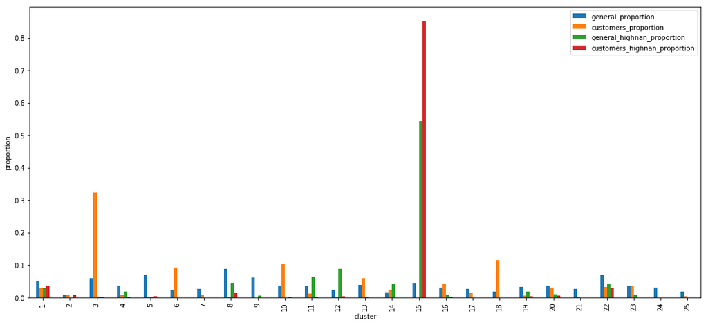

```python
# Plot poportions per cluster per dataset
df_proportions.plot(x='cluster', y=['general_proportion',
                                    'customers_proportion',
                                    'general_highnan_proportion',
                                    'customers_highnan_proportion'], kind='bar', figsize=(18,8))
plt.ylabel('proportion')
plt.show()
```

```python
# What kind of people are part of a cluster that is overrepresented in the
# customer data compared to the general population?

# Cluster number 3, customers_proportion is overrepresented compared to general_proportion
# Features associated with this cluster
pca_weights(az_lownan_scaled, pca, 2)
```

```
SEMIO_VERT                  0.294
SEMIO_FAM                   0.245
SEMIO_SOZ                   0.242
SEMIO_KULT                  0.239
FINANZTYP_5                 0.132
ZABEOTYP_1                  0.127
FINANZ_MINIMALIST           0.124
GREEN_AVANTGARDE            0.121
SEMIO_REL                   0.116
SHOPPER_TYP_0.0             0.112
LP_STATUS_GROB_5.0          0.098
LP_STATUS_FEIN_10.0         0.098
ORTSGR_KLS9                 0.092
EWDICHTE                    0.091
SEMIO_MAT                   0.090
RETOURTYP_BK_S              0.062
PLZ8_ANTG3                  0.060
PLZ8_ANTG4                  0.060
PLZ8_BAUMAX_5.0             0.053
LP_STATUS_GROB_3.0          0.050
W_KEIT_KIND_HH              0.048
SHOPPER_TYP_1.0             0.048
RELAT_AB                    0.046
PLZ8_ANTG2                  0.045
ARBEIT                      0.043
LP_LEBENSPHASE_FEIN_20.0    0.043
LP_LEBENSPHASE_FEIN_13.0    0.041
LP_LEBENSPHASE_FEIN_40.0    0.040
ZABEOTYP_6                  0.040
LP_LEBENSPHASE_FEIN_35.0    0.040
                            ...
SHOPPER_TYP_3.0            -0.046
GEBAEUDETYP_RASTER         -0.048
LP_LEBENSPHASE_FEIN_21.0   -0.052
PLZ8_ANTG1                 -0.053
LP_STATUS_GROB_2.0         -0.053
ZABEOTYP_3                 -0.054
LP_FAMILIE_FEIN_4.0        -0.054
PLZ8_BAUMAX_1.0            -0.057
KKK                        -0.057
ZABEOTYP_4                 -0.060
KONSUMNAEHE                -0.061
HH_EINKOMMEN_SCORE         -0.066
LP_STATUS_FEIN_2.0         -0.068
WOHNLAGE_7.0               -0.070
BALLRAUM                   -0.071
FINANZ_HAUSBAUER           -0.073
LP_FAMILIE_GROB_3.0        -0.078
LP_LEBENSPHASE_GROB_6.0    -0.078
INNENSTADT                 -0.078
SHOPPER_TYP_2.0            -0.086
FINANZTYP_1                -0.088
LP_STATUS_FEIN_4.0         -0.099
MOVEMENT                   -0.121
SEMIO_RAT                  -0.128
FINANZ_ANLEGER             -0.145
SEMIO_ERL                  -0.203
SEMIO_DOM                  -0.249
SEMIO_KRIT                 -0.251
SEMIO_KAEM                 -0.283
ANREDE_KZ                  -0.317
Name: 2, Length: 257, dtype: float64
```

```python
# Cluster number 15, customers_highnan_proportion is overrepresented compared to the others
# Features associated with this cluster
pca_weights(az_lownan_scaled, pca, 14)
```

```
LIFE_STAGE                  0.355
CAMEO_DEUG_2015_3           0.238
CAMEO_DEUG_2015_6           0.174
CAMEO_DEU_2015_3D           0.155
LP_LEBENSPHASE_FEIN_6.0     0.154
CAMEO_DEU_2015_6E           0.128
CAMEO_DEU_2015_3C           0.127
LP_STATUS_GROB_1.0          0.121
CAMEO_DEU_2015_8D           0.117
LP_STATUS_FEIN_1.0          0.114
LP_LEBENSPHASE_GROB_11.0    0.111
KBA13_ANZAHL_PKW            0.111
LP_LEBENSPHASE_GROB_9.0     0.106
FINANZTYP_3                 0.106
CAMEO_DEUG_2015_1           0.104
MIN_GEBAEUDEJAHR            0.103
CAMEO_DEU_2015_3A           0.101
PLZ8_HHZ                    0.092
CAMEO_DEU_2015_8C           0.091
LP_LEBENSPHASE_FEIN_29.0    0.088
CAMEO_DEU_2015_9E           0.086
WOHNLAGE_0.0                0.085
LP_LEBENSPHASE_GROB_2.0     0.083
CAMEO_DEU_2015_6B           0.079
KBA05_ANTG4                 0.075
SHOPPER_TYP_3.0             0.074
ANZ_HAUSHALTE_AKTIV         0.072
LP_LEBENSPHASE_FEIN_34.0    0.071
PLZ8_GBZ                    0.071
CAMEO_DEU_2015_6C           0.071
                            ...
CAMEO_DEU_2015_4C          -0.061
KBA05_ANTG2                -0.062
KBA05_ANTG1                -0.064
FINANZ_MINIMALIST          -0.065
LP_LEBENSPHASE_FEIN_7.0    -0.067
MOBI_REGIO                 -0.067
CAMEO_DEU_2015_9B          -0.070
CAMEO_DEUG_2015_5          -0.071
LP_STATUS_FEIN_4.0         -0.073
CAMEO_DEU_2015_9C          -0.073
WEALTH                     -0.077
CAMEO_DEU_2015_9D          -0.077
LP_LEBENSPHASE_FEIN_37.0   -0.078
LP_LEBENSPHASE_FEIN_39.0   -0.081
LP_LEBENSPHASE_GROB_1.0    -0.083
PLZ8_BAUMAX_5.0            -0.084
FINANZTYP_6                -0.085
SHOPPER_TYP_2.0            -0.085
HEALTH_TYP                 -0.086
LP_LEBENSPHASE_FEIN_4.0    -0.093
LP_STATUS_FEIN_3.0         -0.093
KBA05_GBZ                  -0.095
LP_STATUS_GROB_2.0         -0.096
CAMEO_DEUG_2015_9          -0.105
CAMEO_DEU_2015_4A          -0.112
CAMEO_DEUG_2015_4          -0.127
LP_LEBENSPHASE_GROB_12.0   -0.132
CAMEO_DEU_2015_7B          -0.162
CAMEO_DEU_2015_7A          -0.195
CAMEO_DEUG_2015_7          -0.247
Name: 14, Length: 257, dtype: float64
```

```python
# What kinds of people are part of a cluster that is underrepresented in the
# customer data compared to the general population?

# Cluster number 5, customers_proportion is underrepresented compared to general_proportion
# Features associated with this cluster
pca_weights(az_lownan_scaled, pca, 4)
```

```
MOVEMENT                    0.215
LP_FAMILIE_GROB_5.0         0.192
ANZ_PERSONEN                0.187
KKK                         0.166
LP_FAMILIE_FEIN_10.0        0.157
LP_STATUS_FEIN_9.0          0.148
LP_LEBENSPHASE_GROB_10.0    0.135
LP_STATUS_GROB_4.0          0.133
REGIOTYP                    0.127
LP_LEBENSPHASE_FEIN_31.0    0.119
HH_EINKOMMEN_SCORE          0.105
LP_LEBENSPHASE_FEIN_37.0    0.105
WEALTH                      0.099
FINANZTYP_6                 0.098
LP_LEBENSPHASE_FEIN_38.0    0.094
LP_LEBENSPHASE_GROB_9.0     0.094
LP_LEBENSPHASE_GROB_4.0     0.089
LP_LEBENSPHASE_FEIN_29.0    0.086
LP_LEBENSPHASE_GROB_12.0    0.086
LP_FAMILIE_FEIN_11.0        0.082
WOHNLAGE_7.0                0.082
LP_LEBENSPHASE_FEIN_15.0    0.080
BALLRAUM                    0.078
LP_FAMILIE_FEIN_2.0         0.076
LP_FAMILIE_GROB_2.0         0.076
LP_LEBENSPHASE_FEIN_19.0    0.076
OST_WEST_KZ                 0.074
LP_STATUS_FEIN_1.0          0.073
SEMIO_VERT                  0.072
LP_LEBENSPHASE_FEIN_34.0    0.072
                            ...
KBA05_ANTG1                -0.060
LP_LEBENSPHASE_FEIN_4.0    -0.062
PLZ8_GBZ                   -0.062
CAMEO_DEU_2015_1D          -0.063
CAMEO_DEUG_2015_2          -0.065
LP_STATUS_FEIN_3.0         -0.065
SEMIO_RAT                  -0.067
PLZ8_HHZ                   -0.070
CAMEO_DEU_2015_2D          -0.073
LP_LEBENSPHASE_FEIN_3.0    -0.073
LP_LEBENSPHASE_FEIN_10.0   -0.078
SEMIO_KAEM                 -0.081
ANREDE_KZ                  -0.081
ORTSGR_KLS9                -0.083
LP_LEBENSPHASE_FEIN_1.0    -0.086
SEMIO_KRIT                 -0.087
EWDICHTE                   -0.089
FINANZ_UNAUFFAELLIGER      -0.092
CAMEO_DEUG_2015_1          -0.095
SEMIO_DOM                  -0.102
WOHNLAGE_1.0               -0.102
W_KEIT_KIND_HH             -0.120
LP_LEBENSPHASE_GROB_1.0    -0.139
LP_LEBENSPHASE_GROB_3.0    -0.144
LP_LEBENSPHASE_FEIN_13.0   -0.160
LP_STATUS_FEIN_10.0        -0.187
LP_STATUS_GROB_5.0         -0.187
GREEN_AVANTGARDE           -0.215
LP_FAMILIE_FEIN_1.0        -0.241
LP_FAMILIE_GROB_1.0        -0.241
Name: 4, Length: 257, dtype: float64
```

```python
# Cluster number 13, customers_highnan_proportion is underrepresented compared to the others
# Features associated with this cluster
pca_weights(az_lownan_scaled, pca, 12)
```

```
KBA13_ANZAHL_PKW            0.355
PLZ8_HHZ                    0.324
PLZ8_GBZ                    0.323
LP_STATUS_FEIN_1.0          0.178
LP_LEBENSPHASE_FEIN_5.0     0.135
KBA05_ANTG2                 0.131
LP_STATUS_GROB_1.0          0.103
CAMEO_DEUG_2015_7           0.103
PLZ8_ANTG2                  0.098
NATIONALITAET_KZ_2.0        0.095
PLZ8_BAUMAX_1.0             0.094
ZABEOTYP_6                  0.093
LP_LEBENSPHASE_GROB_2.0     0.089
FINANZTYP_5                 0.087
RETOURTYP_BK_S              0.084
FINANZTYP_3                 0.083
PLZ8_ANTG1                  0.083
HEALTH_TYP                  0.081
LP_LEBENSPHASE_GROB_11.0    0.079
CAMEO_DEUG_2015_4           0.079
CAMEO_DEU_2015_4A           0.076
PLZ8_BAUMAX_2.0             0.074
CAMEO_DEU_2015_7A           0.071
FINANZ_VORSORGER            0.070
CAMEO_DEU_2015_7B           0.068
LP_LEBENSPHASE_FEIN_31.0    0.065
SHOPPER_TYP_2.0             0.065
SEMIO_MAT                   0.060
GFK_URLAUBERTYP_10.0        0.059
GFK_URLAUBERTYP_8.0         0.058
                            ...
LP_LEBENSPHASE_FEIN_25.0   -0.053
WOHNLAGE_7.0               -0.055
LP_STATUS_FEIN_4.0         -0.056
LP_LEBENSPHASE_FEIN_8.0    -0.056
RELAT_AB                   -0.056
CAMEO_DEU_2015_6E          -0.057
SHOPPER_TYP_0.0            -0.057
LP_STATUS_FEIN_5.0         -0.057
CAMEO_DEU_2015_8C          -0.064
KONSUMNAEHE                -0.065
ZABEOTYP_5                 -0.066
LP_LEBENSPHASE_FEIN_3.0    -0.066
FINANZ_ANLEGER             -0.074
CAMEO_DEU_2015_8D          -0.074
CAMEO_DEUG_2015_3          -0.076
PLZ8_ANTG4                 -0.077
FINANZ_HAUSBAUER           -0.079
LP_STATUS_FEIN_2.0         -0.080
SHOPPER_TYP_3.0            -0.081
LP_LEBENSPHASE_FEIN_1.0    -0.084
NATIONALITAET_KZ_1.0       -0.087
LP_LEBENSPHASE_GROB_1.0    -0.088
PLZ8_BAUMAX_4.0            -0.097
CAMEO_DEU_2015_3D          -0.099
LP_STATUS_GROB_2.0         -0.101
FINANZTYP_6                -0.101
PLZ8_BAUMAX_5.0            -0.102
LIFE_STAGE                 -0.126
ARBEIT                     -0.164
OST_WEST_KZ                -0.328
Name: 12, Length: 257, dtype: float64
```

### Discussion 3.3: Compare Customer Data to Demographics Data

**The graph shows the proportions of each dataset in the predicted clusters to give them relative meaning to each other, only using the counts would not allow for a good comparison because they differ so much among the datasets. I have included the datasets that have a lot of NaN values because we saw earlier that they do seem to differ from the subset that had no NaN values, and excluding these would give a biased view on the total general population and total customer population. There are differences in the datasets across many of the clusters and I have decided to go more in depth on a few:**

**In cluster number 3, the customers_proportion is overrepresented compared to the general_proportion. This cluster is associated with people far away from having a dreamful (*SEMIO_VERT*) and family-oriented (*SEMIO_FAM*) personality type. This cluster would be a target audience for the company.**

**Looking at cluster number 15, the customers_highnan_proportion is very overrepresented compared to the general_proportion and all the other datasets. This cluster is associated with elders in retirement (*LIFE_STAGE*) that are established middle class (*CAMEO_DEUG_2015_3*). This subset of the customer data shows a distinct difference from the other customer data and has to be considered as a very strong target audience for the company.**

**For cluster number 5, both customer datasets (customers_proportion and customers_highnan_proportions) are underrepresented compared to the general_proportion. This cluster is associated with people belonging to the mainstream movement during that person’s youth (*MOVEMENT*) and a multiperson household family type (*LP_FAMILIE_GROB_5.0*). This means that the total customer base is underrepresented compared to the general population and that this is a demographic group that the company should not target.**

**In cluster number 13, customers_highnan_proportion is underrepresented compared to the other datasets, so both compared to the general population dataset and the customer dataset that has few NaNs. However, the customers_proportion is overrepresented in this cluster compared to the other datasets. This cluster is associated with a high number of cars (*KBA13_ANZAHL_PKW*) and households (*PLZ8_HHZ*) within the PLZ8 region. The fact that one subset of the customer data is underrepresented here meanwhile another is overrepresented might indicate that there are two distinct customer groups with different characteristics that the company should look more into and understand to be able to target correctly. So they have one subset of their customer data (customers_highnan_proportion) that indicates that this is not a demographic group the company should target, meanwhile another subset (customers_proportion) indicates that this is indeed a target group, they just have to figure out how these customer bases differ in other ways to clearly distinguish and target the correct population.**

> Congratulations on making it this far in the project! Before you finish, make sure to check through the entire notebook from top to bottom to make sure that your analysis follows a logical flow and all of your findings are documented in **Discussion** cells. Once you've checked over all of your work, you should export the notebook as an HTML document to submit for evaluation. You can do this from the menu, navigating to **File -> Download as -> HTML (.html)**. You will submit both that document and this notebook for your project submission.

```python
!!jupyter nbconvert *.ipynb
```

```
['[NbConvertApp] Converting notebook Identify_Customer_Segments.ipynb to html',
 '[NbConvertApp] Writing 1422746 bytes to Identify_Customer_Segments.html']
```